# Covid19JHU

Dhanushga Lionel

6/19/2021

## COVID-19 R Markdown

I will start by reading in the data from the four main .csv files from the JHU COVID-19 Github page. We will also need the library(tidyverse) package.

Let’s read in the data and see what we have.

```r
library(tidyverse)
global_cases <- read.csv("https://raw.githubusercontent.com/CSSEGISandData/COVID-19/master/csse_covid_19_data/csse_covid_19_time_series/time_series_covid19_confirmed_global.csv")
global_deaths <- read.csv("https://raw.githubusercontent.com/CSSEGISandData/COVID-19/master/csse_covid_19_data/csse_covid_19_time_series/time_series_covid19_deaths_global.csv")
US_cases <- read.csv("https://raw.githubusercontent.com/CSSEGISandData/COVID-19/master/csse_covid_19_data/csse_covid_19_time_series/time_series_covid19_confirmed_US.csv")
US_deaths <- read.csv("https://raw.githubusercontent.com/CSSEGISandData/COVID-19/master/csse_covid_19_data/csse_covid_19_time_series/time_series_covid19_deaths_US.csv")
```

After looking at the global_cases, and global_deaths, I would like to tidy those datasets, and put each variable (date, cases, deaths) in their own column.

Also I don’t need Lat and Long for the analysis I am planning, so I will get rid of those and rename Region and State to be more R-friendly

```r
global_cases <- global_cases %>%
     pivot_longer(cols = -c(`Province.State`,
                           `Country.Region`, Lat, Long),
                 names_to = "date",
                 values_to = "cases") %>%
     select(-c(Lat,Long))


global_deaths <- global_deaths %>%
     pivot_longer(cols = -c(`Province.State`,
                           `Country.Region`, Lat, Long),
                 names_to = "date",
                 values_to = "deaths") %>%
     select(-c(Lat,Long))
```

Combining global_cases and global_deaths together in another variable called global. We will first need the package library(lubridate)

```r
library(lubridate)
global <- global_cases %>%
    full_join(global_deaths) %>%
    rename(Country_Region = `Country.Region`,
           Province_State = `Province.State`) %>%
    mutate(date=mdy(str_sub(date, 2)))
```

Look at the summary of the global data.

```r
summary(global)
```

```
##  Province_State     Country_Region          date                cases
##  Length:142892      Length:142892      Min.   :2020-01-22   Min.   :       0
##  Class :character   Class :character   1st Qu.:2020-05-29   1st Qu.:      90
##  Mode  :character   Mode  :character   Median :2020-10-04   Median :    1482
##                                        Mean   :2020-10-04   Mean   :  208098
##                                        3rd Qu.:2021-02-10   3rd Qu.:   31871
##                                        Max.   :2021-06-18   Max.   :33516175
##      deaths
##  Min.   :     0
##  1st Qu.:     1
##  Median :    22
##  Mean   :  5048
##  3rd Qu.:   564
##  Max.   :601571
```

Filter out rows where there are no cases. There should only be rows where cases are positive. Then check the summary.

```r
global <- global %>% filter(cases > 0)
summary(global)
```

```
##  Province_State     Country_Region          date                cases
##  Length:127588      Length:127588      Min.   :2020-01-22   Min.   :       1
##  Class :character   Class :character   1st Qu.:2020-06-29   1st Qu.:     265
##  Mode  :character   Mode  :character   Median :2020-10-27   Median :    2700
##                                        Mean   :2020-10-25   Mean   :  233059
##                                        3rd Qu.:2021-02-22   3rd Qu.:   47256
##                                        Max.   :2021-06-18   Max.   :33516175
##      deaths
##  Min.   :     0
##  1st Qu.:     2
##  Median :    48
##  Mean   :  5654
##  3rd Qu.:   796
##  Max.   :601571
```

Check to see if Maximum cases is possible (>33,000,000)

```r
global %>% filter(cases > 33000000)
```

```
## # A tibble: 32 x 5
##    Province_State Country_Region date          cases deaths
##    <chr>          <chr>          <date>        <int>  <int>
##  1 ""             US             2021-05-18 33001039 587174
##  2 ""             US             2021-05-19 33030332 587843
##  3 ""             US             2021-05-20 33060540 588521
##  4 ""             US             2021-05-21 33088492 589134
##  5 ""             US             2021-05-22 33108291 589625
##  6 ""             US             2021-05-23 33121157 589819
##  7 ""             US             2021-05-24 33146976 590261
##  8 ""             US             2021-05-25 33169715 590888
##  9 ""             US             2021-05-26 33193687 591861
## 10 ""             US             2021-05-27 33221141 593210
## # ... with 22 more rows
```

Want to do the same thing for the United States. First look what is in US_cases.

```r
US_cases
```

[output not shown]

[output cut: 12592 more lines]

Now we want to tidy up the data. We are going to pivot the columns to make it more R friendly.

```r
US_cases %>%
  pivot_longer(cols = -(UID:Combined_Key),
               names_to = "date",
               values_to = "cases")
```

```
## # A tibble: 1,717,788 x 13
##         UID iso2  iso3  code3  FIPS Admin2  Province_State Country_Region   Lat
##       <int> <chr> <chr> <int> <dbl> <chr>   <chr>          <chr>          <dbl>
##  1 84001001 US    USA     840  1001 Autauga Alabama        US              32.5
##  2 84001001 US    USA     840  1001 Autauga Alabama        US              32.5
##  3 84001001 US    USA     840  1001 Autauga Alabama        US              32.5
##  4 84001001 US    USA     840  1001 Autauga Alabama        US              32.5
##  5 84001001 US    USA     840  1001 Autauga Alabama        US              32.5
##  6 84001001 US    USA     840  1001 Autauga Alabama        US              32.5
##  7 84001001 US    USA     840  1001 Autauga Alabama        US              32.5
##  8 84001001 US    USA     840  1001 Autauga Alabama        US              32.5
##  9 84001001 US    USA     840  1001 Autauga Alabama        US              32.5
## 10 84001001 US    USA     840  1001 Autauga Alabama        US              32.5
## # ... with 1,717,778 more rows, and 4 more variables: Long_ <dbl>,
## #   Combined_Key <chr>, date <chr>, cases <int>
```

Need to change a couple things.

1. Get rid of Lat and Long_
2. Change date from character to date object
3. Select Admin2 to cases

```r
US_cases <- US_cases %>%
  pivot_longer(cols = -(UID:Combined_Key),
               names_to = "date",
               values_to = "cases") %>%
  select(Admin2:cases) %>%
  mutate(date=mdy(str_sub(date, 2))) %>%
  select(-c(Lat, Long_))
```

Do the same thing and clean up US_deaths

```r
US_deaths <- US_deaths %>%
  pivot_longer(cols = -(UID:Population),
               names_to = "date",
               values_to = "deaths") %>%
  select(Admin2:deaths) %>%
  mutate(date=mdy(str_sub(date, 2))) %>%
  select(-c(Lat, Long_))
```

Join US_cases and US_deaths into 1 data set called US

```r
US <- US_cases %>%
  full_join(US_deaths)
```

We have population data for the US dataset, but not for the Global dataset. To do comparative analysis, we need to get population data for the Global dataset.

First let’s Combine the Combined_Key with Province_State and Country_Region

```r
global <- global %>%
  unite("Combined_Key",
        c(Province_State, Country_Region),
        sep = ", ",
        na.rm = TRUE,
        remove = FALSE)
```

Now we will add the population to the Global data set. The same github repo for the JHU files has a .csv file with the population data.

```r
uid_lookup_url <- "https://raw.githubusercontent.com/CSSEGISandData/COVID-19/master/csse_covid_19_data/UID_ISO_FIPS_LookUp_Table.csv"

uid <- read_csv(uid_lookup_url) %>%
  select(-c(Lat, Long_, Combined_Key, code3, iso2, iso3, Admin2))
```

Need to clean it up so that Province_State is "" and not NA. This will help to get Population in the Global df. This was a workaround I found, otherwise I was getting errors.

```r
uid$Province_State[is.na(uid$Province_State)] <- ""
```

Join population to Global dataset

```r
global <- global %>%
  left_join(uid, by = c("Province_State", "Country_Region")) %>%
  select(-c(UID, FIPS)) %>%
  select(Province_State, Country_Region, date,
         cases, deaths, Population, Combined_Key)

global
```

```
## # A tibble: 127,588 x 7
##    Province_State Country_Region date       cases deaths Population Combined_Key
##    <chr>          <chr>          <date>     <int>  <int>      <dbl> <chr>
##  1 ""             Afghanistan    2020-02-24     1      0   38928341 , Afghanist~
##  2 ""             Afghanistan    2020-02-25     1      0   38928341 , Afghanist~
##  3 ""             Afghanistan    2020-02-26     1      0   38928341 , Afghanist~
##  4 ""             Afghanistan    2020-02-27     1      0   38928341 , Afghanist~
##  5 ""             Afghanistan    2020-02-28     1      0   38928341 , Afghanist~
##  6 ""             Afghanistan    2020-02-29     1      0   38928341 , Afghanist~
##  7 ""             Afghanistan    2020-03-01     1      0   38928341 , Afghanist~
##  8 ""             Afghanistan    2020-03-02     1      0   38928341 , Afghanist~
##  9 ""             Afghanistan    2020-03-03     2      0   38928341 , Afghanist~
## 10 ""             Afghanistan    2020-03-04     4      0   38928341 , Afghanist~
## # ... with 127,578 more rows
```

Now we need to visualize the dataset. We will start with the US data set. Analyzing the US by state by state, region and date. Then we will add another column called deaths_per_mill.

```r
US_by_state <- US %>%
  group_by(Province_State, Country_Region, date) %>%
  summarize(cases = sum(cases), deaths = sum(deaths),
            Population = sum(Population)) %>%
  mutate(deaths_per_mill = deaths * 1000000 / Population) %>%
  select(Province_State, Country_Region, date, cases, deaths, deaths_per_mill, Population) %>%
  ungroup()
US_by_state
```

```
## # A tibble: 29,812 x 7
##    Province_State Country_Region date       cases deaths deaths_per_mill
##    <chr>          <chr>          <date>     <int>  <int>           <dbl>
##  1 Alabama        US             2020-01-22     0      0               0
##  2 Alabama        US             2020-01-23     0      0               0
##  3 Alabama        US             2020-01-24     0      0               0
##  4 Alabama        US             2020-01-25     0      0               0
##  5 Alabama        US             2020-01-26     0      0               0
##  6 Alabama        US             2020-01-27     0      0               0
##  7 Alabama        US             2020-01-28     0      0               0
##  8 Alabama        US             2020-01-29     0      0               0
##  9 Alabama        US             2020-01-30     0      0               0
## 10 Alabama        US             2020-01-31     0      0               0
## # ... with 29,802 more rows, and 1 more variable: Population <int>
```

Now look at total of US.

```r
US_totals <- US_by_state %>%
  group_by(Country_Region, date) %>%
  summarize(cases = sum(cases), deaths = sum(deaths),
            Population = sum(Population)) %>%
  mutate(deaths_per_mill = deaths *1000000 / Population) %>%
  select(Country_Region, date, cases, deaths, deaths_per_mill, Population) %>%
  ungroup()
US_totals
```

```
## # A tibble: 514 x 6
##    Country_Region date       cases deaths deaths_per_mill Population
##    <chr>          <date>     <int>  <int>           <dbl>      <int>
##  1 US             2020-01-22     1      1         0.00300  332875137
##  2 US             2020-01-23     1      1         0.00300  332875137
##  3 US             2020-01-24     2      1         0.00300  332875137
##  4 US             2020-01-25     2      1         0.00300  332875137
##  5 US             2020-01-26     5      1         0.00300  332875137
##  6 US             2020-01-27     5      1         0.00300  332875137
##  7 US             2020-01-28     5      1         0.00300  332875137
##  8 US             2020-01-29     6      1         0.00300  332875137
##  9 US             2020-01-30     6      1         0.00300  332875137
## 10 US             2020-01-31     8      1         0.00300  332875137
## # ... with 504 more rows
```

Filter where there were cases. X variable will be date, and the y variable will have both cases and deaths. To get a sense of the graph, it will be scaled on a log10 factor.

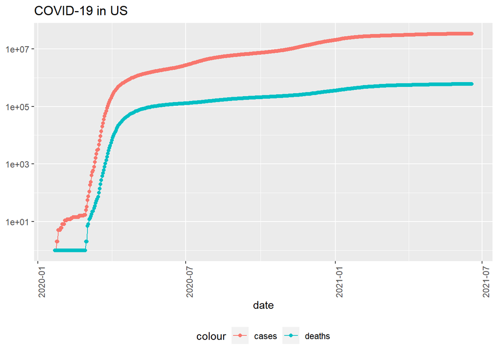

```r
US_totals %>%
  filter(cases > 0) %>%
  ggplot(aes(x = date, y = cases)) +
  geom_line(aes(color = "cases")) +
  geom_point(aes(color = "cases")) +
  geom_line(aes(y = deaths, color = "deaths")) +
  geom_point(aes(y = deaths, color = "deaths")) +
  scale_y_log10() +
  theme(legend.position = "bottom",
        axis.text.x = element_text(angle = 90)) +
  labs(title = "COVID-19 in US", y = NULL)
```

Now we will be doing it by state.

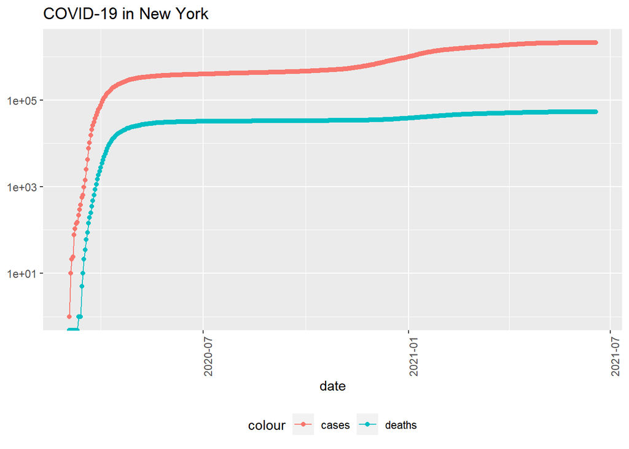

```r
state <- "New York"
US_by_state %>%
  filter(Province_State == state) %>%
  filter (cases > 0) %>%
  ggplot(aes(x = date, y = cases)) +
  geom_line(aes(color = "cases")) +
  geom_point(aes(color = "cases")) +
  geom_line(aes(y = deaths, color = "deaths")) +
  geom_point(aes(y = deaths, color = "deaths")) +
  scale_y_log10() +
  theme(legend.position = "bottom",
        axis.text.x = element_text(angle = 90)) +
  labs(title = str_c("COVID-19 in ", state), y = NULL)
```

Maximum us total by date and deaths

```r
max(US_totals$date)
```

```
## [1] "2021-06-18"
```

```r
max(US_totals$deaths)
```

```
## [1] 601571
```

We will now transform our data again, by adding new variables. We will be adding 2 new columns, new_cases and new_deaths.

```r
US_by_state <- US_by_state %>%
  mutate(new_cases = cases - lag(cases),
         new_deaths = deaths - lag(deaths))
US_totals <- US_totals %>%
  mutate(new_cases = cases - lag(cases),
         new_deaths = deaths - lag(deaths))

tail(US_totals %>% select(new_cases, new_deaths, everything()))
```

```
## # A tibble: 6 x 8
##   new_cases new_deaths Country_Region date          cases deaths deaths_per_mill
##       <int>      <int> <chr>          <date>        <int>  <int>           <dbl>
## 1      4775        111 US             2021-06-13 33462003 599776           1802.
## 2     12731        170 US             2021-06-14 33474734 599946           1802.
## 3     11304        339 US             2021-06-15 33486038 600285           1803.
## 4     12430        368 US             2021-06-16 33498468 600653           1804.
## 5     10399        281 US             2021-06-17 33508867 600934           1805.
## 6      7308        637 US             2021-06-18 33516175 601571           1807.
## # ... with 1 more variable: Population <int>
```

Now we will visualize the US new cases and new deaths. We can see it is not just flat, but is going down.

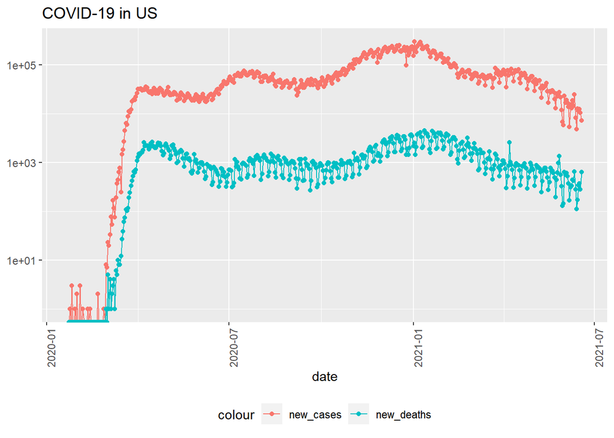

```r
US_totals %>%
  ggplot(aes(x = date, y = new_cases)) +
  geom_line(aes(color = "new_cases")) +
  geom_point(aes(color="new_cases")) +
  geom_line(aes(y = new_deaths, color = "new_deaths")) +
  geom_point(aes(y = new_deaths, color = "new_deaths")) +
  scale_y_log10() +
  theme(legend.position = "bottom",
        axis.text.x = element_text(angle = 90)) +
  labs(title = "COVID-19 in US", y=NULL)
```

Do the same thing for a particular state. See new cases and new deaths for New York.

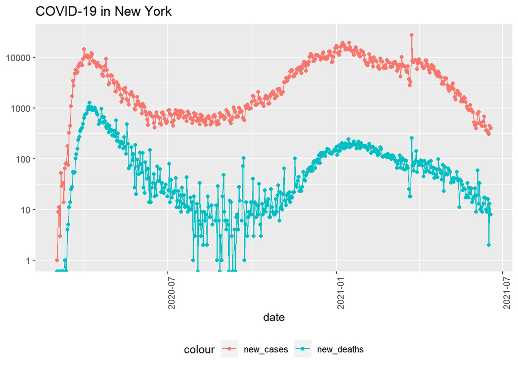

```r
state <- "New York"
US_by_state %>%
  filter(Province_State == state) %>%
  filter (cases > 0) %>%
  ggplot(aes(x = date, y = new_cases)) +
  geom_line(aes(color = "new_cases")) +
  geom_point(aes(color = "new_cases")) +
  geom_line(aes(y = new_deaths, color = "new_deaths")) +
  geom_point(aes(y = new_deaths, color = "new_deaths")) +
  scale_y_log10() +
  theme(legend.position = "bottom",
        axis.text.x = element_text(angle = 90)) +
  labs(title = str_c("COVID-19 in ", state), y = NULL)
```

Now we want to see the states with the most cases and deaths. We will group by state, and choose max deaths and cases.

```r
US_state_totals <- US_by_state %>%
  group_by(Province_State) %>%
  summarize(deaths = max(deaths), cases = max(cases),
            population = max(Population),
            cases_per_thou = 1000 * cases / population,
            deaths_per_thou = 1000 * deaths / population) %>%
  filter(cases > 0, population > 0)

US_state_totals %>%
  slice_min(deaths_per_thou, n = 10) %>%
  select(deaths_per_thou, cases_per_thou, everything())
```

```
## # A tibble: 10 x 6
##    deaths_per_thou cases_per_thou Province_State        deaths  cases population
##              <dbl>          <dbl> <chr>                  <int>  <int>      <int>
##  1          0.0363           3.32 Northern Mariana Isl~      2    183      55144
##  2          0.280           35.0  Virgin Islands            30   3752     107268
##  3          0.360           26.3  Hawaii                   510  37214    1415872
##  4          0.410           39.0  Vermont                  256  24360     623989
##  5          0.503           95.6  Alaska                   373  70875     740995
##  6          0.635           51.1  Maine                    854  68756    1344212
##  7          0.652           48.9  Oregon                  2750 206299    4217737
##  8          0.676           37.2  Puerto Rico             2539 139669    3754939
##  9          0.726          128.   Utah                    2326 411071    3205958
## 10          0.769           58.7  Washington              5856 446682    7614893
```

```r
US_state_totals %>%
  slice_max(deaths_per_thou, n = 10) %>%
  select(deaths_per_thou, cases_per_thou, everything())
```

```
## # A tibble: 10 x 6
##    deaths_per_thou cases_per_thou Province_State deaths   cases population
##              <dbl>          <dbl> <chr>           <int>   <int>      <int>
##  1            2.97          115.  New Jersey      26368 1020830    8882190
##  2            2.76          109.  New York        53597 2111162   19453561
##  3            2.61          103.  Massachusetts   17960  709263    6892503
##  4            2.57          144.  Rhode Island     2724  152383    1059361
##  5            2.48          108.  Mississippi      7371  319948    2976149
##  6            2.45          122.  Arizona         17822  888701    7278717
##  7            2.32           97.8 Connecticut      8270  348665    3565287
##  8            2.31          112.  Alabama         11306  548657    4903185
##  9            2.30          103.  Louisiana       10688  477453    4648794
## 10            2.29          141.  South Dakota     2027  124393     884659
```

Now we will do some modelling. Linear modelling is predicting the values of a particular variable from other variables. We will be looking at the deaths per thousand as a function of the cases per thousand. We will then make a grid from 1 to 151 and put that into a tibble.

```r
mod <- lm(deaths_per_thou ~ cases_per_thou, data = US_state_totals)
summary(mod)
```

```
##
## Call:
## lm(formula = deaths_per_thou ~ cases_per_thou, data = US_state_totals)
##
## Residuals:
##      Min       1Q   Median       3Q      Max
## -1.41734 -0.21700 -0.02963  0.20816  1.04927
##
## Coefficients:
##                 Estimate Std. Error t value Pr(>|t|)
## (Intercept)    -0.013320   0.212192  -0.063     0.95
## cases_per_thou  0.016816   0.002123   7.922 1.49e-10 ***
## ---
## Signif. codes:  0 '***' 0.001 '**' 0.01 '*' 0.05 '.' 0.1 ' ' 1
##
## Residual standard error: 0.4655 on 53 degrees of freedom
## Multiple R-squared:  0.5422, Adjusted R-squared:  0.5335
## F-statistic: 62.76 on 1 and 53 DF,  p-value: 1.49e-10
```

```r
US_state_totals %>% slice_min(cases_per_thou)
```

```
## # A tibble: 1 x 6
##   Province_State          deaths cases population cases_per_thou deaths_per_thou
##   <chr>                    <int> <int>      <int>          <dbl>           <dbl>
## 1 Northern Mariana Islan~      2   183      55144           3.32          0.0363
```

```r
US_state_totals %>% slice_max(cases_per_thou)
```

```
## # A tibble: 1 x 6
##   Province_State deaths  cases population cases_per_thou deaths_per_thou
##   <chr>           <int>  <int>      <int>          <dbl>           <dbl>
## 1 North Dakota     1554 110544     762062           145.            2.04
```

```r
x_grid <- seq(1, 151)
new_df <- tibble(cases_per_thous = x_grid)
US_state_totals %>% mutate(pred = predict(mod))
```

```
## # A tibble: 55 x 7
##    Province_State  deaths  cases population cases_per_thou deaths_per_thou  pred
##    <chr>            <int>  <int>      <int>          <dbl>           <dbl> <dbl>
##  1 Alabama          11306 5.49e5    4903185          112.            2.31   1.87
##  2 Alaska             373 7.09e4     740995           95.6           0.503  1.60
##  3 Arizona          17822 8.89e5    7278717          122.            2.45   2.04
##  4 Arkansas          5874 3.45e5    3017804          114.            1.95   1.91
##  5 California       63274 3.81e6   39512223           96.3           1.60   1.61
##  6 Colorado          6723 5.53e5    5758736           96.1           1.17   1.60
##  7 Connecticut       8270 3.49e5    3565287           97.8           2.32   1.63
##  8 Delaware          1679 1.10e5     973764          112.            1.72   1.88
##  9 District of Co~   1141 4.92e4     705749           69.8           1.62   1.16
## 10 Florida          37555 2.34e6   21477737          109.            1.75   1.82
## # ... with 45 more rows
```

```r
US_tot_w_pred <- US_state_totals %>% mutate(pred = predict(mod))
```

Now we will plot the actual and the prediction

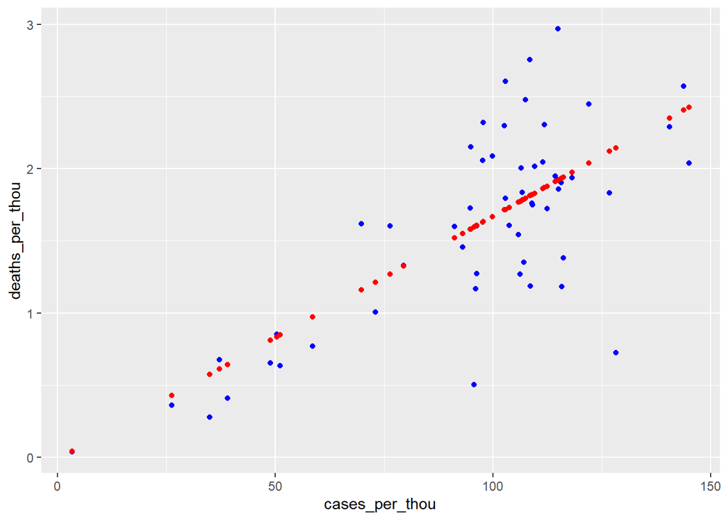

```r
US_tot_w_pred %>%
  ggplot() +
  geom_point(aes(x = cases_per_thou, y = deaths_per_thou), color = "blue") +
  geom_point(aes(x = cases_per_thou, y = pred), color = "red")
```